# Лабораторная работа №6

Установка и настройка системы управления базами данных MariaDB

Жукова Арина Александровна

1132239120@rudn.ru

Российский университет дружбы народов

2025-12-21

# Информация

## Докладчик

- Жукова Арина Александровна
- студентка 3 курса
- направление: Прикладная информатика
- Российский университет дружбы народов им. П. Лумумбы
- 1132239120@rudn.ru

[figure not shown]

# Вводная часть

## Актуальность

- MariaDB — одна из самых популярных систем управления базами данных с открытым исходным кодом
- Полная совместимость с MySQL делает её востребованной в веб-разработке
- Управление базами данных — ключевой навык для системных администраторов и разработчиков
- Автоматизация развёртывания БД повышает надёжность и воспроизводимость инфраструктуры

## Объект и предмет исследования

- **Объект**: Система управления базами данных MariaDB
- **Предмет**: Процесс установки, настройки и администрирования СУБД MariaDB

## Цели и задачи

**Цель**: Приобретение практических навыков по установке и конфигурированию системы управления базами данных на примере MariaDB.

**Задачи**:

1. Установить и настроить MariaDB с кодировкой UTF-8
2. Создать тестовую базу данных с таблицей и пользователем
3. Освоить работу с резервными копиями баз данных
4. Автоматизировать процесс развёртывания через скрипты Vagrant
5. Проверить работоспособность всех компонентов

## Материалы и методы

- Виртуальные машины (Server и Client) на Rocky Linux
- ПО: MariaDB Server 10.11.11, клиентские утилиты
- Язык запросов: SQL
- Инструменты администрирования: mysql, mysqlshow, mysqldump
- Система автоматизации: Vagrant с bash-скриптами

# Установка MariaDB

## Установка пакетов

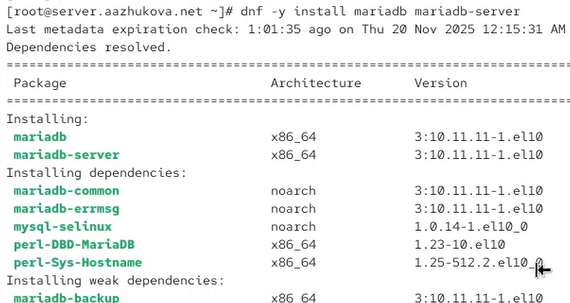

- Установлены основные пакеты:
  - `mariadb` — клиентские утилиты
  - `mariadb-server` — сервер MariaDB
- Версия: 10.11.11-MariaDB
- Автоматическое разрешение зависимостей
- Установлены дополнительные модули

## Архитектура конфигурации

**Основной файл конфигурации**

```
/etc/my.cnf:
[client-server]
!includedir /etc/my.cnf.d
```

- Модульная архитектура конфигурации
- Все настройки в отдельных файлах в `/etc/my.cnf.d/`
- Легкость управления и обновления

**Ключевые конфигурационные файлы:**

- `mariadb-server.cnf` — настройки сервера
- `client.cnf` — настройки клиентов
- `mysql-clients.cnf` — настройки утилит
- `utf8.cnf` — настройки кодировки (создан)

## Запуск и активация службы

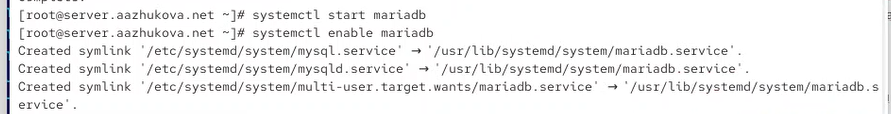

Рисунок 1

- Запуск службы: `systemctl start mariadb`
- Включение в автозагрузку: `systemctl enable mariadb`
- Создание системных символических ссылок

**Проверка состояния**

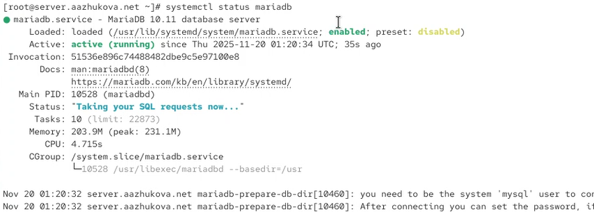

- Служба активна (running)
- PID процесса: 10528
- Использование памяти: 203.9M
- Время работы: 35 секунд

## Настройка безопасности

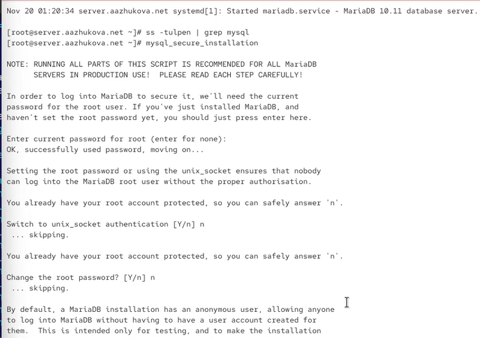

# Настройка кодировки UTF-8

## Создание конфигурационного файла

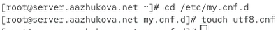

- Создание файла: `touch utf8.cnf`
- Расположение: `/etc/my.cnf.d/`
- Цель: установка UTF-8 как кодировки по умолчанию

**Содержание файла**

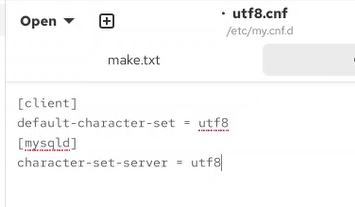

- Настройка для клиентов и сервера
- Поддержка кириллицы и Unicode

## Применение настроек и проверка

**Перезапуск сервера**

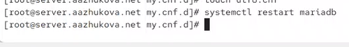

- Применение изменений: `systemctl restart mariadb`
- Проверка отсутствия ошибок

**Проверка кодировки до настройки**

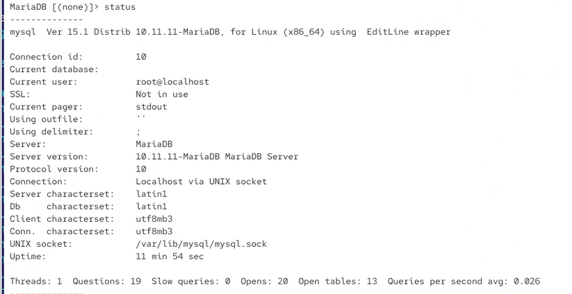

- Server characterset: `latin1`
- Db characterset: `latin1`
- Не поддерживает кириллицу корректно

## Результат настройки кодировки

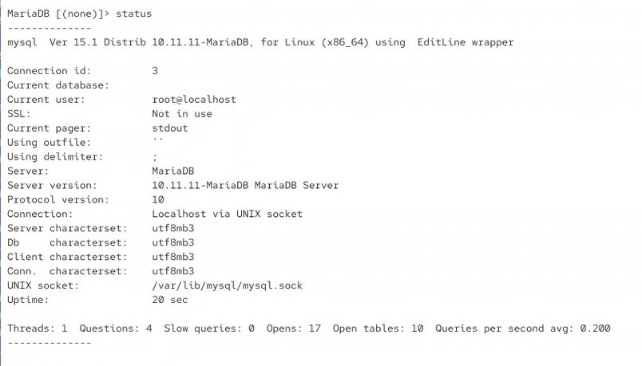

# Создание базы данных

## Создание базы и таблицы

**Создание базы данных**

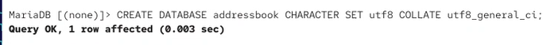

- Имя базы: `addressbook`
- Кодировка: UTF-8
- Сравнение: `utf8_general_ci`

**Создание таблицы**

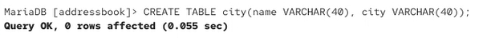

- Две колонки типа VARCHAR(40)
- Для хранения имени и города

## Добавление тестовых данных

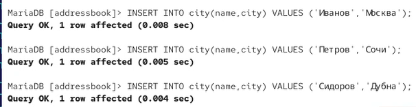

**SQL-запросы:**

- Три тестовые записи
- Проверка работы с кириллицей
- Подтверждение работы UTF-8

**Проверка данных**

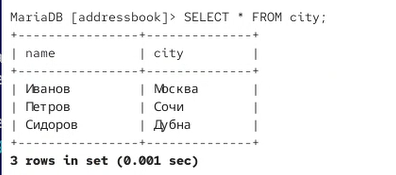

- Успешное отображение кириллицы
- Все три записи корректно сохранены
- Подтверждение целостности данных

## Управление пользователями

**Создание пользователя**

[figure not shown]

- Имя пользователя: `aazhukova`
- Доступ с любого хоста: `%`
- Пароль: `123456`

**Назначение прав**

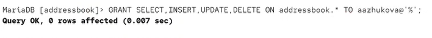

## Проверка доступа

**Список всех баз данных**

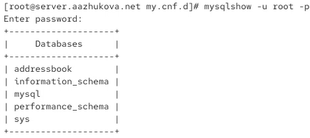

- Системные базы: `information_schema`, `mysql`, `performance_schema`, `sys`
- Созданная база: `addressbook`
- Всего 5 баз данных

**Доступ пользователя aazhukova**

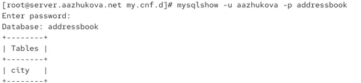

- Успешный доступ к базе `addressbook`
- Отображение таблицы `city`
- Подтверждение корректных прав доступа

# Работа с резервными копиями

## Создание резервных копий

**Создание каталога для бэкапов**

- Централизованное хранение резервных копий
- Структурированное управление бэкапами

**SQL-дамп базы данных**

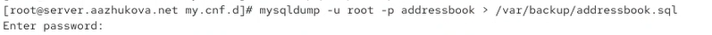

- Полный дамп структуры и данных
- Текстовый формат SQL
- Возможность редактирования

## Сжатые резервные копии

**Сжатый дамп (gzip)**

- Экономия места на диске
- Автоматическое сжатие потоком
- Быстрое создание и восстановление

**Дамп с датой в имени**

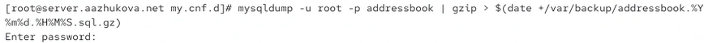

- Автоматическое именование по дате
- Ведение истории бэкапов
- Удобное восстановление на определённую дату

## Восстановление из резервных копий

**Восстановление из SQL-дампа**

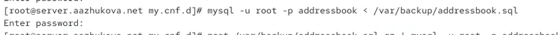

- Полное восстановление структуры и данных
- Простая команда восстановления
- Проверка целостности бэкапа

**Восстановление из сжатого дампа**

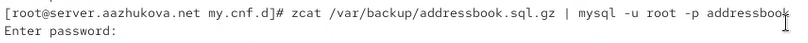

- Распаковка на лету
- Экономия времени и места
- Удобство работы с большими базами

# Автоматизация развёртывания

## Подготовка конфигурации

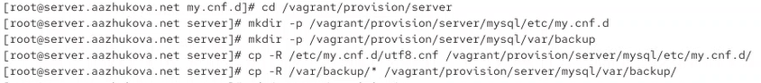

**Копирование конфигурационных файлов:**

- Сохранение настроек кодировки UTF-8
- Сохранение резервных копий базы данных
- Обеспечение воспроизводимости развёртывания

## Создание скрипта автоматизации

**Создание и настройка скрипта**

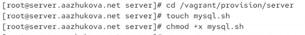

- Создание исполняемого файла
- Настройка прав доступа
- Подготовка к интеграции с Vagrant

**Структура скрипта mysql.sh:**

1. Установка пакетов MariaDB
2. Копирование конфигурации
3. Запуск и настройка службы
4. Настройка безопасности
5. Создание базы данных
6. Восстановление из бэкапа

## Интеграция с Vagrant

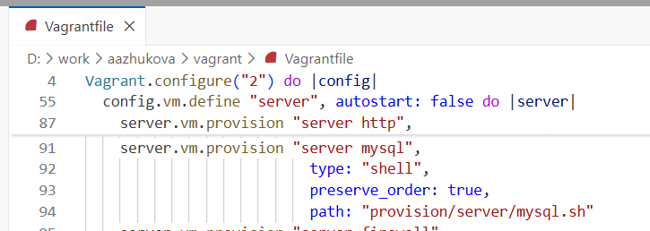

- Автоматический запуск при развёртывании
- Сохранение порядка выполнения (после HTTP)
- Полная автоматизация процесса настройки
- Воспроизводимость окружения

# Результаты

## Проверка работоспособности

- Успешный доступ к базе данных через клиентские утилиты
- Корректное отображение кириллических символов
- Работоспособность созданного пользователя
- Возможность создания и восстановления резервных копий
- Автоматическое применение конфигурации при перезапуске

# Выводы

## Основные выводы

1. **MariaDB как современная СУБД**
   - Легко устанавливается и настраивается в среде Rocky Linux
   - Полная совместимость с MySQL упрощает миграцию
   - Модульная архитектура конфигурации повышает гибкость
2. **Кодировка UTF-8 — обязательный стандарт**
   - Критически важна для поддержки кириллицы и Unicode
   - Простая настройка через конфигурационные файлы
   - Необходима проверка применения настроек
3. **Резервное копирование — критически важно**
   - Регулярные бэкапы защищают от потери данных
   - Сжатые копии экономят место на диске
   - Автоматическое именование упрощает управление историей
4. **Автоматизация — ключ к воспроизводимости**
   - Скрипты автоматизации экономят время
   - Обеспечивают консистентность окружений
   - Упрощают масштабирование и восстановление

## Практическая значимость

- Получены навыки администрирования промышленной СУБД
- Освоены ключевые операции: создание БД, управление пользователями, резервное копирование
- Приобретён опыт интеграции с системами автоматизации (Vagrant)
- Разработана система воспроизводимого развёртывания инфраструктуры
- Полученные знания применимы в реальных проектах веб-разработки и системного администрирования